# MA331-Report: 2212188

TED Talks by Speaker Dong Woo Jang and Speaker Stephen Hawking

Channagiri Nagaraja, Ranjitha

## Introduction

My first speaker Dong Woo Jang who turns a stick of bamboo into an archer’s bow. He spent the first three years developing a habitat for spiders in his room while studying their anatomy and hunting techniques.He gave the speech in the year of 2013. My second speaker Stephen Hawking a popular well-known physicist and cosmologist frequently discusses subjects connected to his study, such as black holes, the beginnings of the cosmos, and the origin of the universe.The talk was given by Stephen Hawking in April 2008.

## Methods

This R code is intended to examine the key phrases said by Dong Woo Jang and Stephen Hawking, two separate presenters in TED Talks. The following packages are loaded in the first line of the code: dsEssex, tidyverse, tidytext, dplyr, ggplot2, ggrepel, and tidyr. The TED Talks dataset is loaded in the next section, which then uses the head() method to display a few rows. The dataset is cleaned up and tokenized in the third part using the unnest_tokens() method, which adds a new row to the dataset’s text column for each distinct word. A new variable named tidy_talks is created as a result.

## Results

```
                          LEVEL 1 - Summary and word counts
```

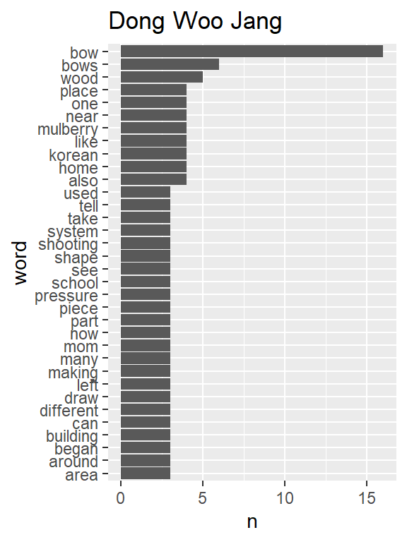

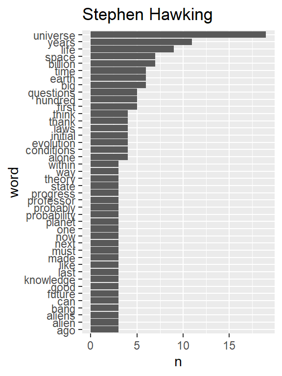

```
   speaker              word                 n
 Length:356         Length:356         Min.   : 1.000
 Class :character   Class :character   1st Qu.: 1.000
 Mode  :character   Mode  :character   Median : 1.000
                                       Mean   : 1.393
                                       3rd Qu.: 1.000
                                       Max.   :16.000
```

```
   speaker              word                 n
 Length:325         Length:325         Min.   : 1.000
 Class :character   Class :character   1st Qu.: 1.000
 Mode  :character   Mode  :character   Median : 1.000
                                       Mean   : 1.575
                                       3rd Qu.: 2.000
                                       Max.   :19.000
```

```
                      LEVEL 2 - Comparisons between the two speakers'
```

[figure not shown]

```
  LEVEL 3 - Deeper comparisons between the two speakers, using numerical and visualize techniques
```

```
# A tibble: 36 × 4
   speaker       word          n sentiment
   <chr>         <chr>     <int> <chr>
 1 Dong Woo Jang like          4 positive
 2 Dong Woo Jang better        2 positive
 3 Dong Woo Jang effective     2 positive
 4 Dong Woo Jang great         2 positive
 5 Dong Woo Jang ideal         2 positive
 6 Dong Woo Jang survival      2 positive
 7 Dong Woo Jang well          2 positive
 8 Dong Woo Jang works         2 positive
 9 Dong Woo Jang bothered      1 negative
10 Dong Woo Jang bothers       1 negative
# ℹ 26 more rows
```

```
# A tibble: 37 × 4
   speaker         word           n sentiment
   <chr>           <chr>      <int> <chr>
 1 Stephen Hawking thank          4 positive
 2 Stephen Hawking good           3 positive
 3 Stephen Hawking like           3 positive
 4 Stephen Hawking progress       3 positive
 5 Stephen Hawking survival       2 positive
 6 Stephen Hawking advantage      1 positive
 7 Stephen Hawking aggressive     1 negative
 8 Stephen Hawking available      1 positive
 9 Stephen Hawking conspiracy     1 negative
10 Stephen Hawking dangerous      1 negative
# ℹ 27 more rows
```

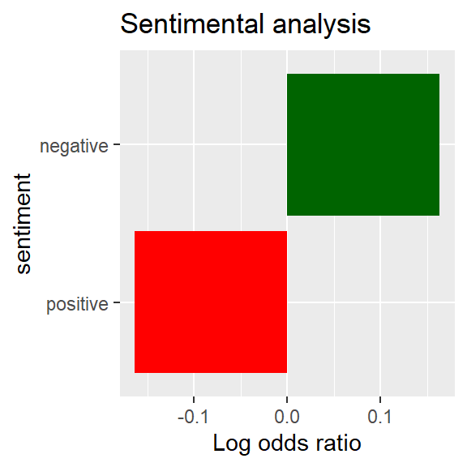

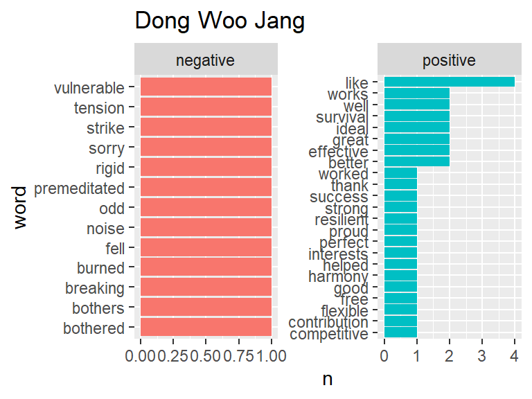

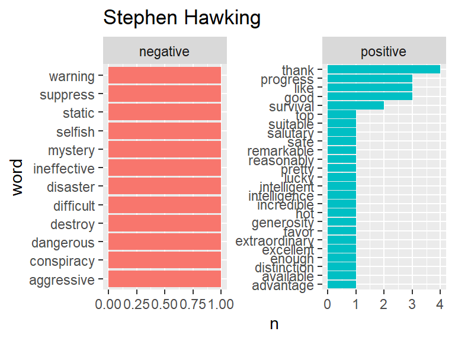

```
 LEVEL 4 - Interpretations and explanations on the general findings and comparisons
```

The code in level 3 is performing sentimental analysis on two sets of data Dong Woo Jang and Stephen Hawking respectively. The code contains positive and Negative words which uses the “bing” lexicon for sentimental analysis. The line illustrates the language they used, both positively and negatively.Dong Woo Jang, the first speaker, used far more positive terms than negative ones when describing how he transformed a stick of bamboo into an archer’s bow.He frequently used positive words like “works well,” “survival”,“ideal,” “great,” “effective,” “better,” etc. The other speaker, Stephen Hawking, who discusses the universe’s beginnings, also used much more encouraging language, such as “thank you,” “progress,” “like,” “good,” and “survival,” among other terms.